# Relatório da Fase 01b: Avaliação do GSE125583 como dataset alternativo para doença de Alzheimer

Pipeline RNA-Seq Neurodegenerativo

2026-10-08

# 1. Introdução

## 1.1 Contexto e motivação

A Fase 01 original utilizou o **GSE53697** para doença de Alzheimer (AD), em conjunto com **GSE64810** para doença de Huntington (HD) e **GSE68719** para doença de Parkinson (PD). No GSE53697, nenhum gene permaneceu significativo após correção por FDR, em um conjunto de apenas 17 amostras.

Esse resultado não significa ausência de biologia no dataset original. **Apesar da baixa potência e do ruído estatístico, sinais biológicos estavam presentes**, como indicado pelos genes com evidência nominal e pelos padrões funcionais observados na Fase 01. A principal limitação era a falta de robustez estatística no nível gene a gene.

A Fase 01b avaliou, portanto, o **GSE125583** como candidato alternativo para AD. A comparação considerou tamanho amostral, qualidade dos dados, universo gênico, expressão diferencial, estabilidade após ajuste por covariáveis, coerência funcional e compatibilidade com HD e PD.

## 1.2 Objetivo

O objetivo foi determinar se o **GSE125583** é tecnicamente e estatisticamente adequado para representar AD nas etapas posteriores do projeto. Foram avaliados o controle de qualidade, a expressão diferencial, o enriquecimento funcional, a comparação com o GSE53697 e, ao final, uma integração exploratória dos DEGs de AD, HD e PD para comparação com o primeiro relatório.

# 2. Auditoria, preparação e harmonização dos dados

## 2.1 Características gerais

Características gerais dos dois datasets de Alzheimer.

| Dataset | Papel | Região | Amostras | AD | Controle | Genes brutos | Genes testáveis |
| --- | --- | --- | --- | --- | --- | --- | --- |
| GSE53697 | AD original | Dorsolateral prefrontal cortex | 17 | 9 | 8 | 19185 | 15811 |
| GSE125583 | AD candidato | Fusiform gyrus | 289 | 219 | 70 | 39376 | 21218 |

O GSE125583 contém **289 amostras**, sendo **219 AD** e **70 controles**, todas provenientes de **giro fusiforme**. Os metadados incluem idade, sexo e estágio de Braak; as ausências pontuais de covariáveis não exigiram remoção de amostras do modelo principal.

## 2.2 Preparação da matriz de contagens

Foi utilizada a matriz `GSE125583_raw_counts_GRCh38.p13_NCBI.tsv.gz`.

A auditoria identificou **39.376 genes e 289 amostras**. As contagens são inteiras e foram utilizadas sem arredondamento. A matriz apresentou bibliotecas entre aproximadamente **8.057.646** e **93.556.289** contagens.

## 2.3 Harmonização com HD e PD

As matrizes brutas de GSE125583, GSE64810 e GSE68719 compartilham os mesmos **39.376 NCBI GeneIDs**. Para manter a integração reproduzível, o **GeneID foi preservado como chave explícita**, independentemente da ordem das linhas.

Esse resultado indica elevada compatibilidade técnica do universo gênico entre os três estudos. A compatibilidade anatômica, entretanto, é diferente e é discutida nas seções de comparação e conclusão.

# 3. Controle de qualidade e pré-filtragem

## 3.1 Critério de pré-filtragem

Genes de baixa expressão foram removidos antes do DESeq2. O critério foi **count ≥ 10 em pelo menos 70 amostras**, sendo 70 o tamanho do menor grupo do GSE125583.

Resumo da pré-filtragem do GSE125583.

| Métrica | Valor |
| --- | --- |
| Genes antes do filtro | 39.376 |
| Genes retidos | 21.218 |
| Genes removidos | 18.158 |
| Percentual retido | 53,89% |
| Amostras retidas | 289 |

Foram mantidos **21.218 genes (53,9%)** e todas as **289 amostras**.

## 3.2 Profundidade de biblioteca e genes detectados

As bibliotecas variaram de **8.057.646** a **93.556.289** contagens, com mediana de **27.754.254**. O número de genes detectados por amostra variou de **22.434** a **30.250**, com mediana de **27.363**.

Não houve diferença significativa entre AD e controles na profundidade de biblioteca (**p = 0,319**). Para genes detectados, o resultado ficou próximo do limiar convencional, mas permaneceu acima de 0,05 (**p = 0,0516**). Esses resultados não forneceram justificativa objetiva para remoção de amostras.

## 3.3 PCA e transformação VST

A PCA foi construída após **VST (variance stabilizing transformation)**. A VST transforma as contagens para reduzir a forte dependência entre média e variância típica de RNA-seq: genes muito abundantes deixam de dominar a distância entre amostras apenas por terem contagens maiores. Isso torna PCA e heatmaps mais interpretáveis.

A VST foi usada **somente para exploração e visualização**; o teste de expressão diferencial continuou sendo realizado pelo DESeq2 sobre as contagens inteiras.

No PCA, **PC1 explicou 26,05%** e **PC2 22,05%** da variância.

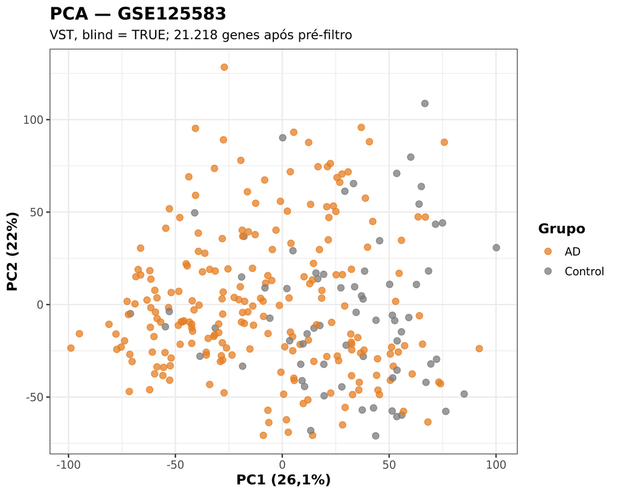

PCA das amostras do GSE125583 após VST, colorida por grupo diagnóstico.

Há sobreposição entre AD e controles, o que não caracteriza falha do dataset: a PCA é não supervisionada e resume todas as fontes de variabilidade presentes no tecido. Considerando o conjunto dos indicadores de QC, **nenhuma amostra foi excluída da análise principal**.

# 4. Expressão diferencial

## 4.1 Estratégia estatística

A expressão diferencial foi analisada com **DESeq2**, comparando AD contra Control, com `Control` como referência. O modelo principal foi **`~ group`** e o teste padrão avaliou a hipótese nula **log₂FC = 0**.

Para interpretar os resultados foram usados três níveis:

- **Significância estatística:** `FDR < 0,05`, independentemente da magnitude do efeito.
- **Critério principal:** `FDR < 0,05` e `|log₂FC| > 0,58`, aproximadamente uma alteração de pelo menos 1,5 vez.
- **Critério estrito (chamado “sensitivity” nos scripts):** `FDR < 0,05` e `|log₂FC| > 1`, correspondente a uma alteração de pelo menos 2 vezes.

Além disso, foi mantido um **critério nominal comparativo** — `p < 0,05` e `|log₂FC| > 1`, sem correção por FDR — apenas para reproduzir a lógica de comparação do relatório original. Ele não substitui o critério principal.

## 4.2 Resultado principal

Resumo da expressão diferencial no GSE125583.

| Critério | GSE125583 |
| --- | --- |
| Genes testados | 21218 |
| Significativos por FDR (< 0,05) | 12731 |
| DEGs principais (FDR < 0,05; \|log2FC\| > 0,58) | 1687 |
| DEGs principais — Up | 763 |
| DEGs principais — Down | 924 |
| DEGs — critério estrito (FDR < 0,05; \|log2FC\| > 1) | 155 |
| Nominal comparativo (p < 0,05; \|log2FC\| > 1) | 155 |

Dos **21.218 genes testados**, **12.731** apresentaram FDR < 0,05. Quando também se exige magnitude mínima de efeito, permanecem **1.687 DEGs principais**, sendo **763 Up** e **924 Down**. Com o limiar mais estrito de `|log₂FC| > 1`, permanecem **155 genes**.

A diferença entre 12.731 genes significativos por FDR e 1.687 DEGs principais ocorre porque uma coorte grande pode detectar efeitos pequenos com alta precisão. O critério principal adiciona um limiar de magnitude para destacar alterações estatisticamente robustas e biologicamente mais expressivas.

## 4.3 MA plot e volcano plot

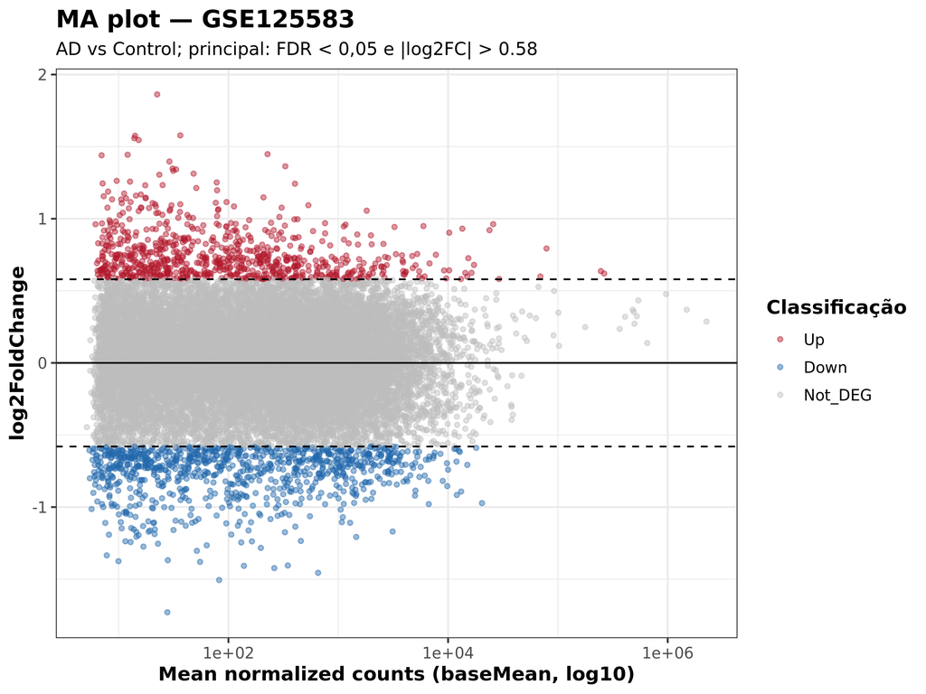

MA plot da comparação AD vs Control no GSE125583.

O MA plot mostra o tamanho do efeito em função da expressão média. Muitos genes são estatisticamente significativos, mas apenas uma fração ultrapassa também o limiar de magnitude do critério principal.

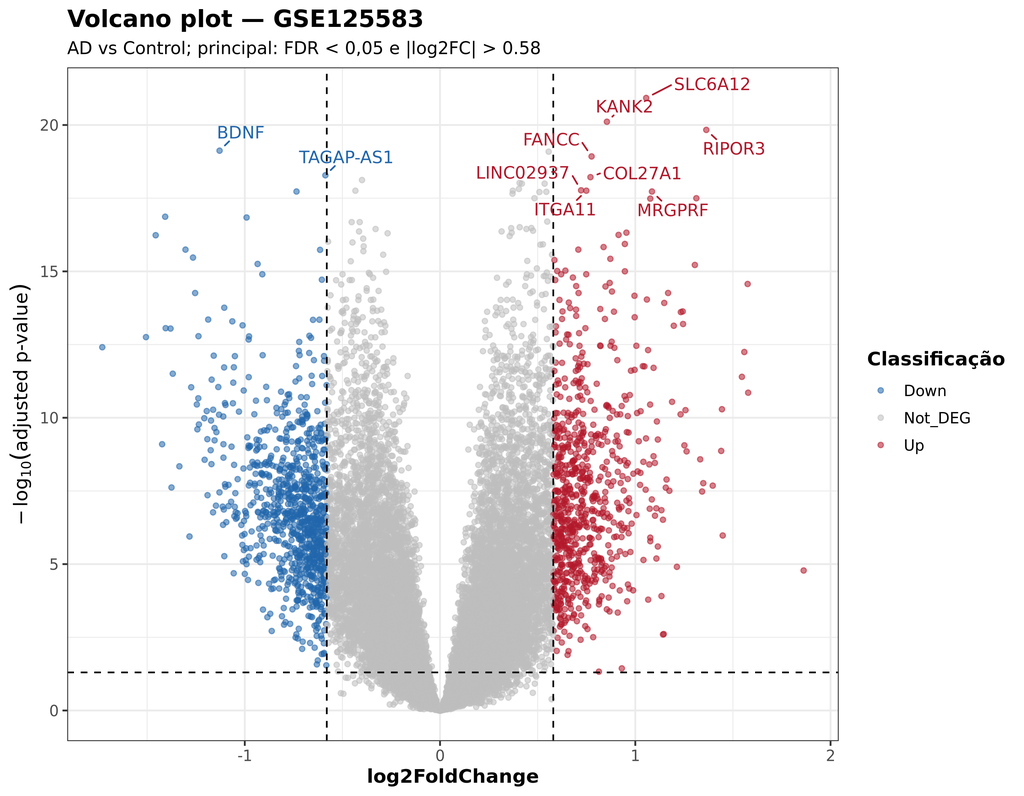

Volcano plot da comparação AD vs Control no GSE125583.

O volcano plot combina magnitude do efeito e significância ajustada, facilitando a visualização dos genes classificados como `Up`, `Down` e `Not_DEG`.

## 4.4 Heatmap dos principais DEGs

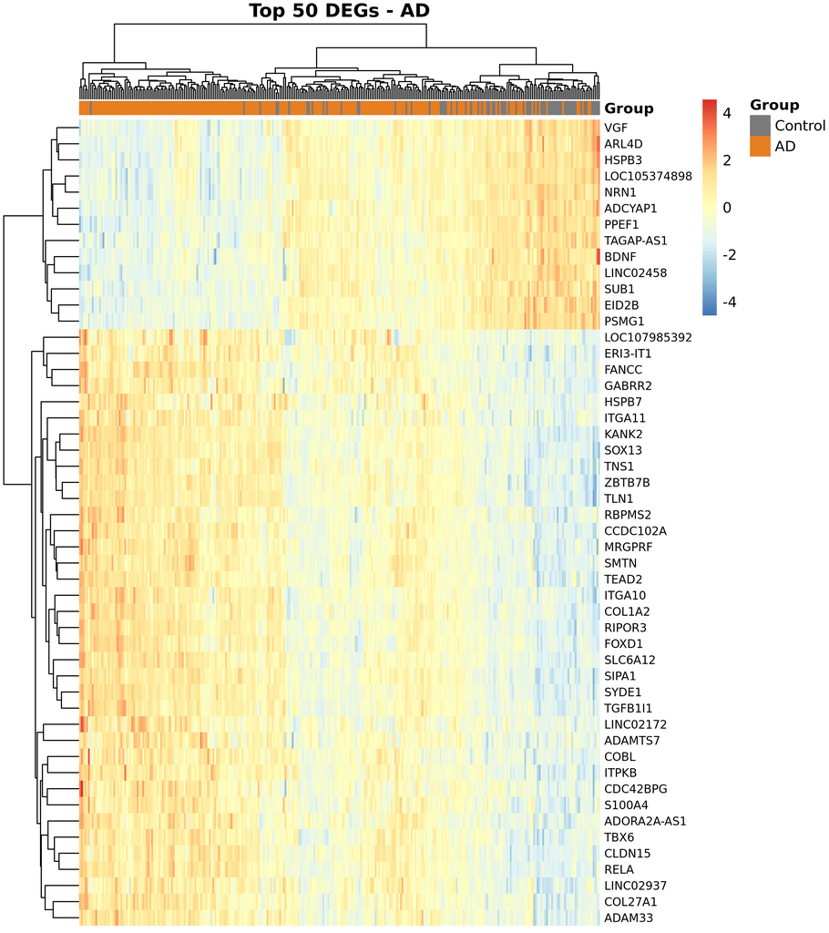

Heatmap dos 50 principais DEGs do GSE125583.

O heatmap utiliza valores transformados por VST e padronizados por gene para destacar padrões relativos entre amostras. Há agrupamento parcial entre AD e controles, compatível com a heterogeneidade observada na PCA. A ausência de separação perfeita não implica ausência de sinal diferencial.

## 4.5 Robustez após ajuste por idade e sexo

Foi executado um segundo modelo, **`~ age_centered + sex + group`**, como verificação de robustez. Uma amostra sem idade e sexo foi excluída apenas desse modelo, resultando em **288 amostras**.

O modelo ajustado identificou **1.540 DEGs principais**. Desses, **1.481** também eram DEGs principais no modelo não ajustado e todos os compartilhados mantiveram a mesma direção de efeito.

A correlação dos log₂FC entre os dois modelos foi **ρ = 0,9946**, indicando estabilidade muito alta.

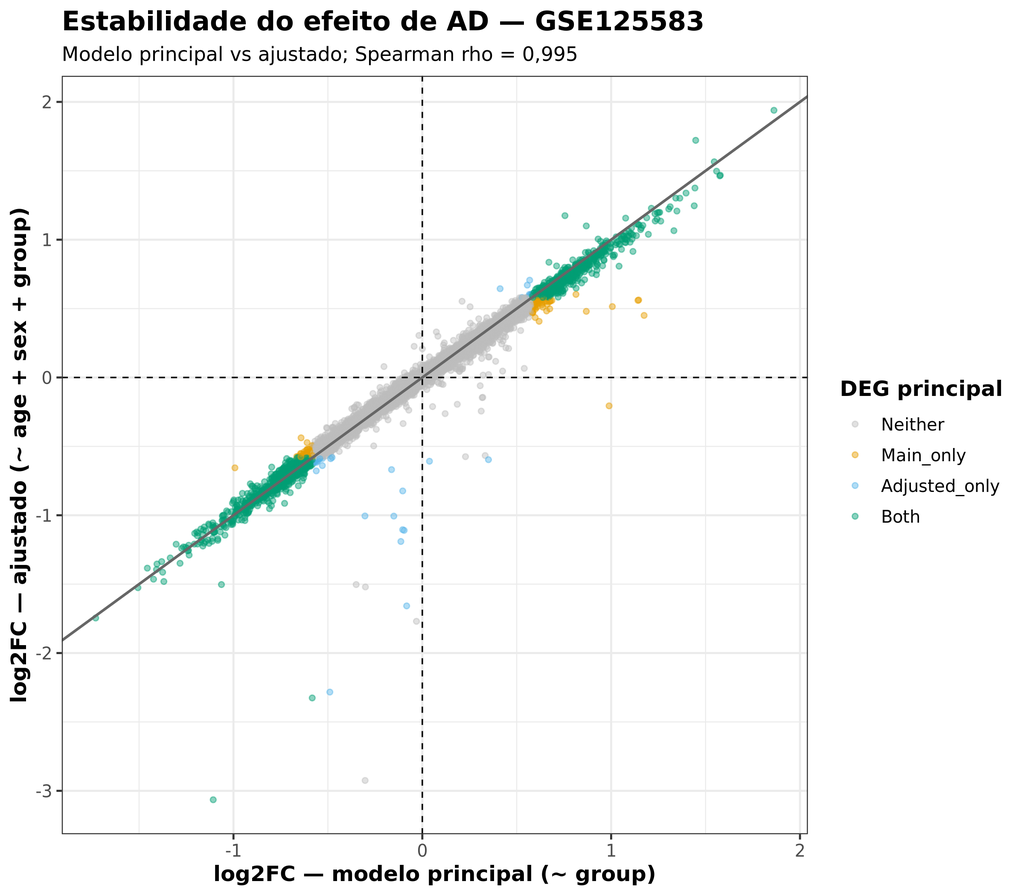

Comparação dos log2FoldChanges entre o modelo principal e o modelo ajustado por idade e sexo.

Portanto, idade e sexo não parecem explicar globalmente a assinatura de AD observada. Braak não foi usado como covariável do modelo principal porque é uma característica neuropatológica diretamente relacionada à doença e seu ajuste poderia remover parte do próprio sinal de interesse.

# 5. Enriquecimento funcional

## 5.1 Estratégia

Foram utilizadas duas abordagens complementares:

- **ORA (Over-Representation Analysis):** testa se determinadas vias/termos aparecem mais do que o esperado entre os DEGs principais;
- **GSEA (Gene Set Enrichment Analysis):** usa o ranking completo dos genes, sem exigir um corte prévio em DEG.

Foram avaliados **GO Biological Process (GO BP)** e **KEGG**. Na ORA, o background foi composto pelos **21.218 genes testados no DESeq2**, e a significância funcional foi controlada por FDR < 0,05.

## 5.2 Resumo quantitativo

Resumo das análises de enriquecimento funcional do GSE125583.

| analysis | n_input_genes | n_terms_total | n_terms_FDR_lt_005 | plot_created |
| --- | --- | --- | --- | --- |
| ORA_GO_BP_all | 1687 | 5032 | 499 | TRUE |
| ORA_GO_BP_up | 763 | 4131 | 467 | TRUE |
| ORA_GO_BP_down | 924 | 4086 | 288 | TRUE |
| ORA_KEGG_all | 1687 | 313 | 25 | TRUE |
| ORA_KEGG_up | 763 | 272 | 13 | TRUE |
| ORA_KEGG_down | 924 | 264 | 32 | TRUE |
| GSEA_GO_BP | 21218 | 5967 | 1716 | TRUE |
| GSEA_KEGG | 21218 | 353 | 165 | TRUE |

GO BP apresentou grande número de termos significativos, especialmente na GSEA. Esses termos não representam mecanismos totalmente independentes, pois categorias de GO frequentemente são redundantes entre si.

## 5.3 Processos aumentados em AD

Os genes com maior expressão em AD mostraram enriquecimento para **resposta imune e citocinas, angiogênese/vasculatura, adesão celular e remodelamento de matriz extracelular**.

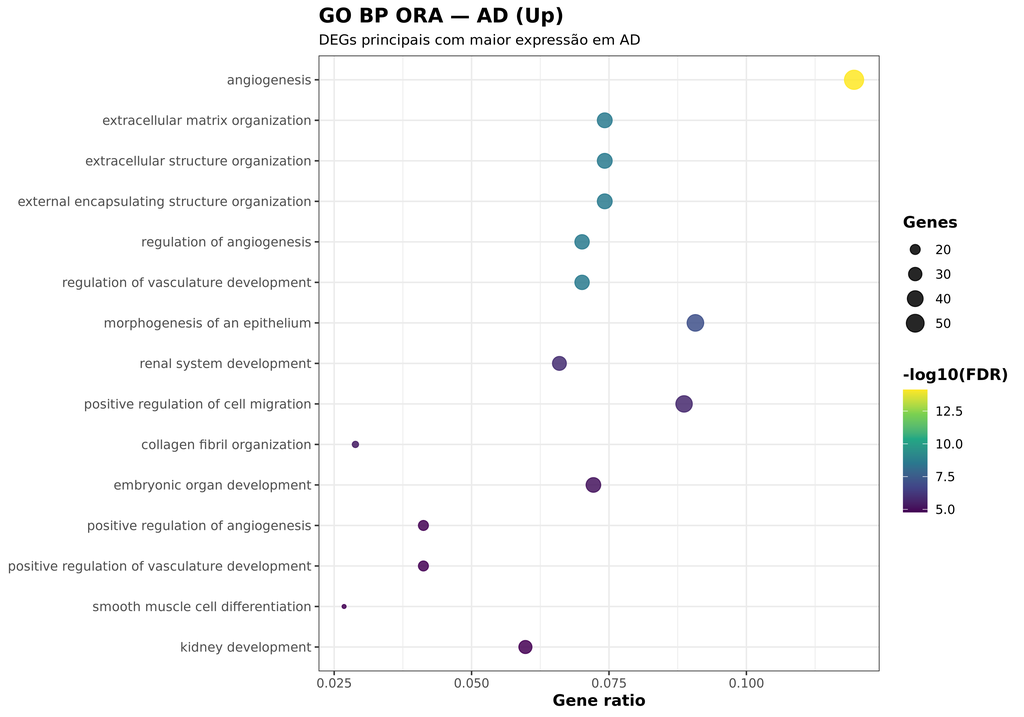

ORA de GO Biological Process para genes com maior expressão em AD.

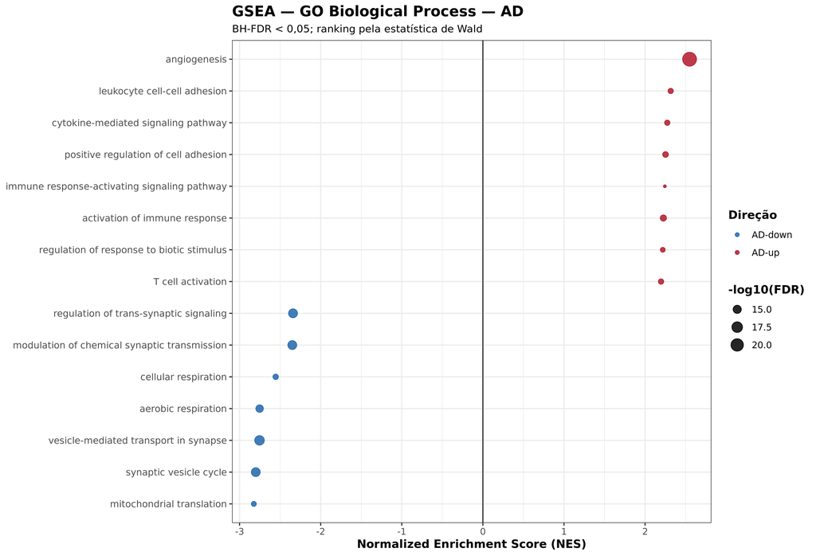

GSEA de GO Biological Process no GSE125583.

A concordância entre ORA e GSEA reforça uma assinatura de ativação imune, vascular e estrutural/remodeladora no tecido de AD.

## 5.4 Processos reduzidos em AD

Os genes com menor expressão em AD foram enriquecidos para **transmissão sináptica, neurotransmissão, ciclo de vesículas, potencial de membrana, respiração celular, fosforilação oxidativa, tradução mitocondrial e proteostase**.

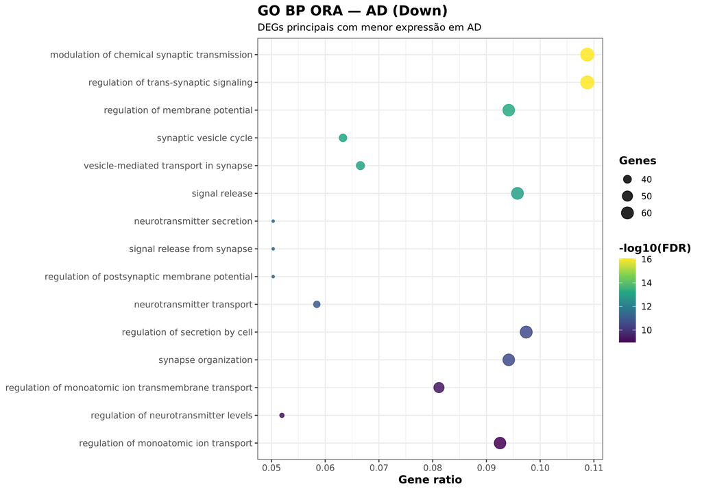

ORA de GO Biological Process para genes com menor expressão em AD.

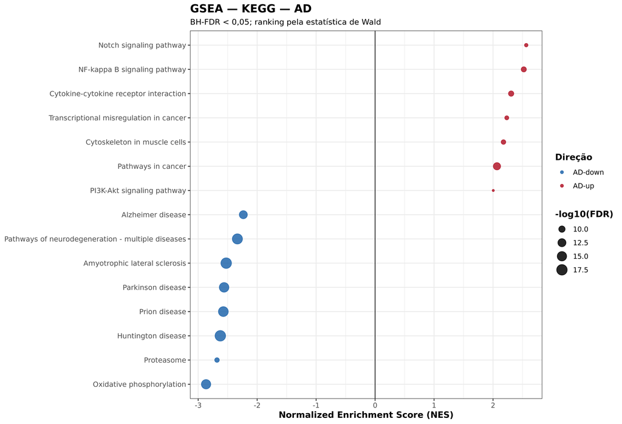

GSEA de KEGG no GSE125583.

Em síntese, a direção funcional predominante foi **AD-up: imunidade/vasculatura/remodelamento** e **AD-down: sinapse/neurotransmissão/metabolismo mitocondrial**.

Como se trata de bulk RNA-seq, essas diferenças podem refletir tanto alterações de expressão dentro das células quanto alterações na proporção dos tipos celulares presentes no tecido.

# 6. Comparação entre GSE53697 e GSE125583

## 6.1 Tamanho amostral

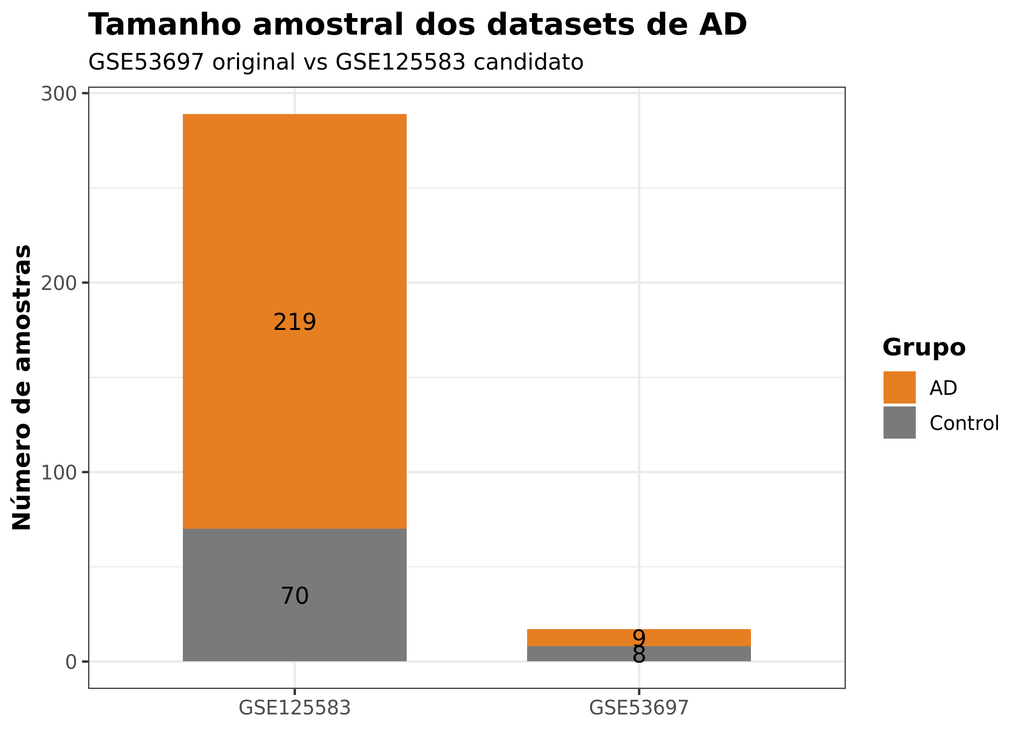

Comparação do tamanho amostral dos dois datasets de Alzheimer.

O GSE53697 contém **17 amostras**, enquanto o GSE125583 contém **289**. O aumento do tamanho amostral eleva substancialmente o poder para detectar alterações após correção para múltiplos testes.

## 6.2 Universo gênico bruto e testável

O universo bruto aumentou de **19.185 genes** no GSE53697 para **39.376** no GSE125583. Após o pré-filtro, os universos testáveis foram **15.811** e **21.218 genes**, respectivamente.

Há **15.147 genes testáveis em ambos** (Jaccard ≈ 0,692), e o GSE125583 adiciona **6.071 genes testáveis** em relação ao conjunto original.

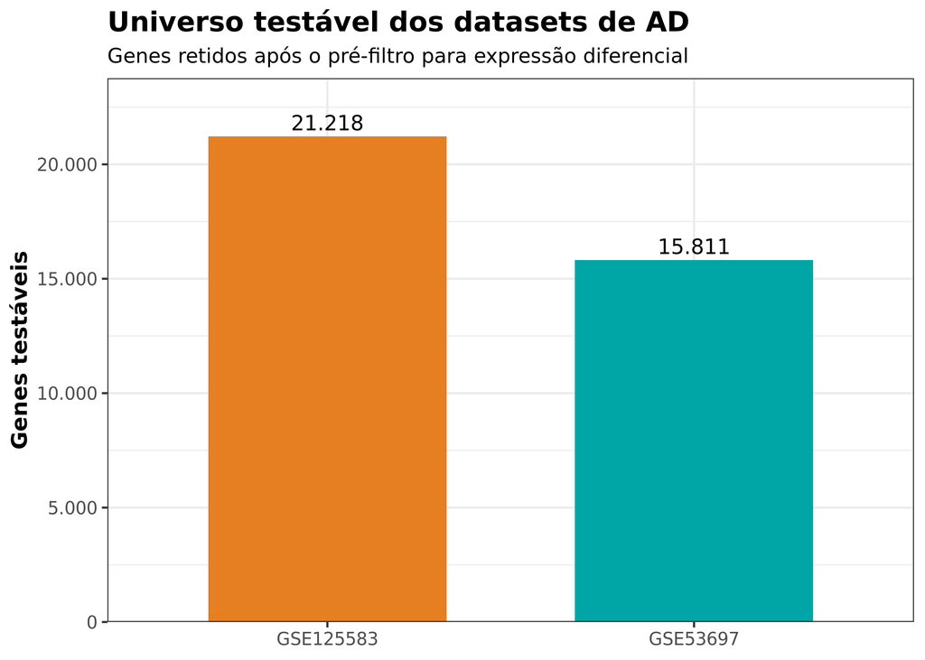

Comparação do universo testável dos dois datasets de Alzheimer.

## 6.3 O que significam as diferentes métricas de DEG?

Comparação dos critérios de expressão diferencial.

| Métrica | GSE53697 | GSE125583 |
| --- | --- | --- |
| Genes testados | 15811 | 21218 |
| FDR < 0,05 | 0 | 12731 |
| Principal: FDR < 0,05 e \|log2FC\| > 0,58 | 0 | 1687 |
| Estrito: FDR < 0,05 e \|log2FC\| > 1 | 0 | 155 |
| Nominal: p < 0,05 e \|log2FC\| > 1 | 52 | 155 |

As linhas da tabela respondem a perguntas diferentes. **FDR < 0,05** indica evidência estatística após corrigir milhares de testes, mas não exige efeito grande. O **critério principal** acrescenta `|log₂FC| > 0,58` para exigir também magnitude mínima. O **critério estrito** aumenta essa exigência para `|log₂FC| > 1` e funciona como teste de sensibilidade: verifica se a conclusão permanece quando só aceitamos efeitos de pelo menos 2 vezes. Já o **critério nominal** não corrige para múltiplos testes e foi mantido apenas para reproduzir a comparação do primeiro relatório.

No GSE53697, nenhum gene sobreviveu ao FDR, embora **52 genes** tenham satisfeito o critério nominal. Isso sugere que **o sinal biológico não estava necessariamente ausente; ele estava imerso em maior incerteza estatística**, compatível com o pequeno tamanho amostral. No GSE125583, **12.731 genes** atingiram FDR < 0,05, **1.687** satisfizeram o critério principal e **155** permaneceram no critério estrito.

No GSE125583, os 155 genes do critério estrito também aparecem no critério nominal; por isso as duas contagens são iguais neste dataset, apesar de os critérios estatísticos serem conceitualmente diferentes.

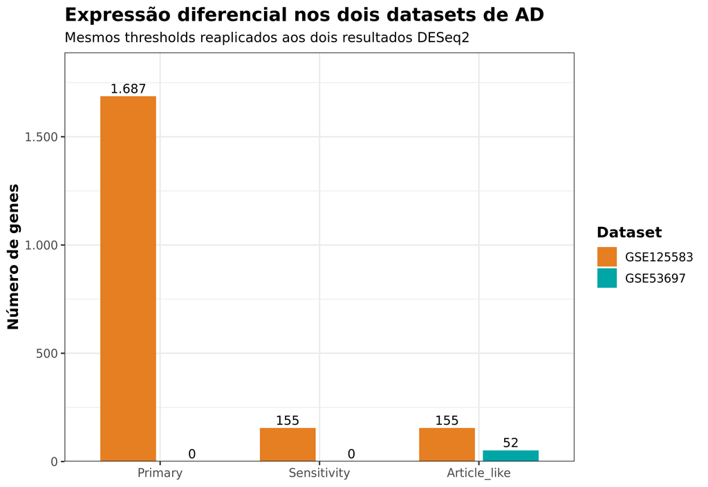

Número de genes classificados segundo os três critérios de expressão diferencial nos dois datasets de AD.

## 6.4 Como interpretar o gráfico de efeito GSE53697 vs GSE125583?

Cada ponto representa **um gene testável nos dois datasets**. O eixo x mostra o log₂FC estimado no GSE53697 e o eixo y mostra o log₂FC do mesmo gene no GSE125583.

A linha diagonal representa concordância perfeita: um gene sobre a linha teria efeito semelhante nos dois estudos. Pontos no mesmo sentido dos dois eixos indicam efeitos com a mesma direção; pontos em sinais opostos indicam direções discordantes. As linhas tracejadas em zero separam genes com aumento e redução de expressão.

As cores destacam o **critério nominal comparativo**: cinza = não satisfaz em nenhum dataset; turquesa = apenas GSE53697; laranja = apenas GSE125583; roxo = ambos.

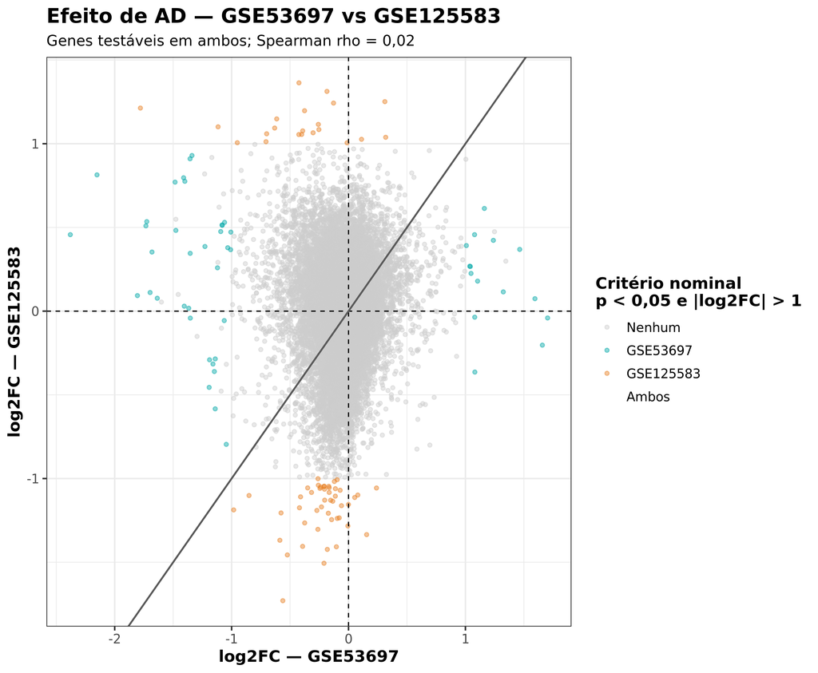

Comparação gene a gene dos log2FoldChanges entre GSE53697 e GSE125583 no universo testável comum.

A correlação global foi **Spearman ρ ≈ 0,02**, e nenhum gene satisfez simultaneamente o critério nominal nos dois datasets dentro do universo testável comum. Portanto, o GSE125583 **não replica a assinatura gene a gene do GSE53697**.

Isso não equivale a dizer que um dos datasets não contém sinal biológico. O GSE53697 possui maior limitação de potência e ruído estatístico, enquanto os dois estudos também diferem em região cerebral, coorte e contexto experimental. A concordância pode ser mais evidente em processos biológicos agregados do que nos mesmos genes individuais.

## 6.5 Compatibilidade gênica com HD e PD

Após os filtros de expressão, a interseção testável entre o novo AD, HD e PD passou de **15.149 genes** com o GSE53697 para **20.576 genes** com o GSE125583 — um ganho de **5.427 genes** potencialmente comparáveis.

Compatibilidade dos universos testáveis entre AD, HD e PD.

| Comparação | Genes testáveis |
| --- | --- |
| AD novo | 21218 |
| HD | 22093 |
| PD | 21322 |
| AD novo ∩ HD | 20801 |
| AD novo ∩ PD | 20579 |
| HD ∩ PD | 21308 |
| AD novo ∩ HD ∩ PD | 20576 |
| AD antigo ∩ HD ∩ PD | 15149 |

Essa melhora é **técnica e gênica**, não anatômica: GSE125583 utiliza giro fusiforme, enquanto GSE64810 e GSE68719 utilizam córtex pré-frontal BA9. Essa diferença é especialmente relevante para interpretações posteriores de composição celular.

# 7. Integração exploratória AD–HD–PD

## 7.1 Por que existem três diagramas de Venn?

Os três Venns respondem a perguntas ligeiramente diferentes:

- **Venn principal harmonizado:** entre os genes que eram testáveis nas três doenças, quais são DEGs com `FDR < 0,05` e `|log₂FC| > 0,58`?
- **Venn estrito harmonizado:** repete a mesma comparação, mas exige `|log₂FC| > 1`.
- **Venn nominal de listas completas:** usa `p < 0,05` e `|log₂FC| > 1` em cada dataset sem limitar previamente ao universo testável comum. Ele foi incluído porque reproduz a lógica da figura do primeiro relatório.

A palavra **harmonizado** significa, portanto, que AD, HD e PD são comparados somente no conjunto de **20.576 genes que puderam ser efetivamente testados nos três estudos**. Isso torna a comparação mais justa entre datasets.

O Venn nominal, por outro lado, pode incluir em uma lista genes que não eram testáveis em outro dataset. Por isso ele é menos apropriado para inferência transdiagnóstica rigorosa, mas é o **mais diretamente comparável ao Venn da Fase 01 original**.

## 7.2 Venn harmonizado — critério principal

No universo comum, as listas contêm **1.553 DEGs em AD**, **1.963 em HD** e **2.615 em PD**. A interseção das três doenças contém **277 genes**.

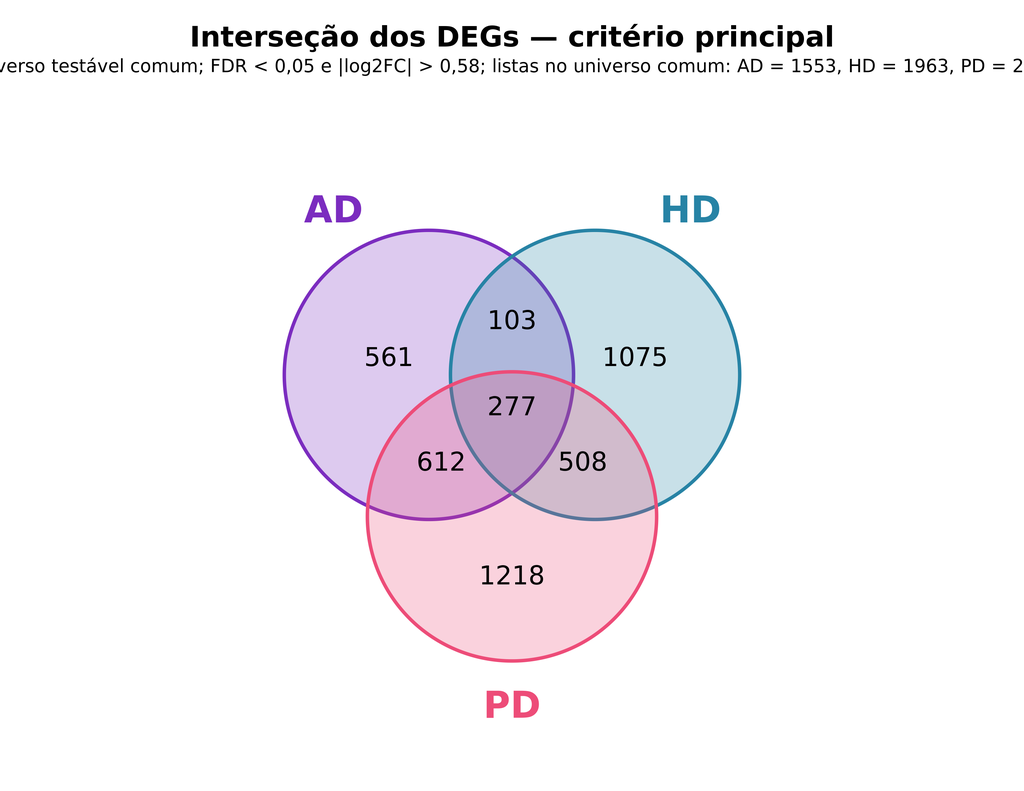

Interseção dos DEGs de AD (GSE125583), HD e PD no universo testável comum — critério principal: FDR < 0,05 e |log2FC| > 0,58.

Este é o Venn mais apropriado para responder quais DEGs são compartilhados quando exigimos **comparabilidade gênica e controle de FDR**.

## 7.3 Venn harmonizado — critério estrito

Com `FDR < 0,05` e `|log₂FC| > 1`, as listas no universo comum contêm **124 genes em AD**, **569 em HD** e **481 em PD**. A interseção tripla contém **17 genes**.

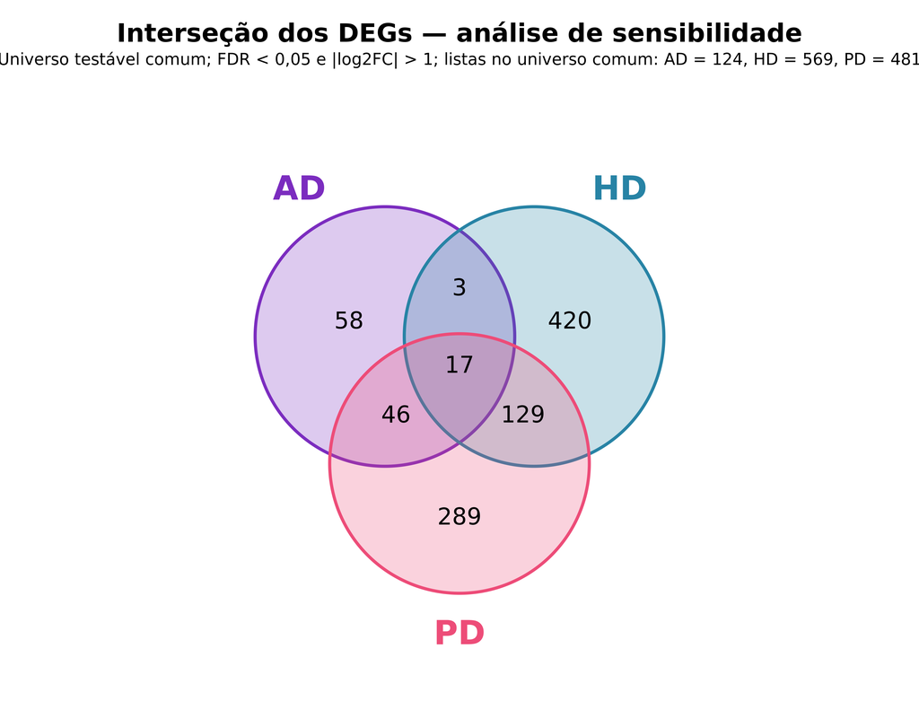

Interseção dos DEGs de AD (GSE125583), HD e PD no universo testável comum — critério estrito: FDR < 0,05 e |log2FC| > 1.

Esse gráfico verifica se as sobreposições permanecem quando se exige uma magnitude de efeito maior.

## 7.4 Venn nominal — comparação direta com o primeiro relatório

O terceiro Venn usa as **listas completas** do critério `p < 0,05` e `|log₂FC| > 1`, exatamente para manter comparabilidade com a figura nominal da Fase 01.

As listas atuais contêm **155 genes em AD**, **701 em HD** e **533 em PD**.

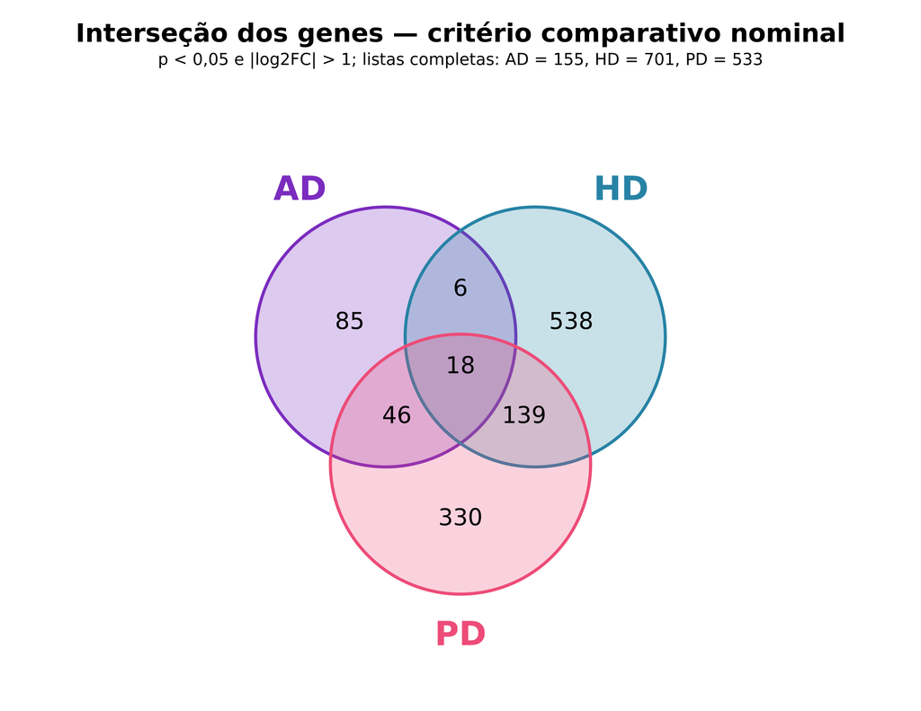

Interseção das listas completas de AD (GSE125583), HD e PD pelo critério nominal p < 0,05 e |log2FC| > 1. Este gráfico é comparável ao Venn nominal da Fase 01 original.

No primeiro relatório, as listas eram **AD = 52, HD = 701 e PD = 533**, com **8 genes compartilhados pelas três doenças**. Com o GSE125583, a interseção tripla é de **18 genes**.

A finalidade deste Venn não é provar que o dataset com maior interseção é biologicamente “melhor”. Ele mostra **quanto a estrutura de sobreposição muda quando trocamos o dataset de AD**, mantendo a mesma regra usada na primeira análise.

# 8. Conclusão da Fase 01b

O GSE125583 mostrou desempenho técnico e estatístico muito superior ao GSE53697: possui 289 amostras, 21.218 genes testáveis, 1.687 DEGs pelo critério principal, alta estabilidade após ajuste por idade e sexo (ρ ≈ 0,995) e uma assinatura funcional coerente, com processos imunes/vasculares aumentados e processos sinápticos/mitocondriais reduzidos.

Ao mesmo tempo, ele **não reproduz a assinatura gene a gene do GSE53697** (ρ ≈ 0,02), e sua região cerebral é diferente daquela utilizada em HD e PD. O GSE125583 é de **giro fusiforme**, enquanto os datasets de HD e PD são de **córtex pré-frontal BA9**.

Assim, a Fase 01b demonstra que o GSE125583 é um candidato robusto e melhora substancialmente a compatibilidade técnica e o universo gênico compartilhado, mas a **heterogeneidade anatômica permanece uma limitação importante**. A integração por Venn foi mantida como documentação comparativa da troca de dataset, sem definir por si só qual conjunto de AD deve ser adotado definitivamente.